# Lab1 CDD - Parlamentares no Twitter

## Introdução

##### A análise desenvolvida nesse relatório trata-se da segunda parte do laboratório 1 da disciplina Ciência de Dados Descritiva do curso de Ciência da Computação da UFCG.

##### Na primeira parte do laboratório cada aluno desenvolveu seis perguntas a cerca dos dados disponibilizados pelo professor. O aluno pôde escolher entre dados que diziam respeito à séries de televisão, retirados do site IMDB, ou dados sobre os *Twitters* de parlamentares no ano de 2019 (os dados foram coletados no dia 22 de março de 2019). Os dados escolhidos por mim foram os dos parlamentares.

##### No desenvolvimento das perguntas na primeira parte do laboratório precisamos escolher um público alvo, cujo escolhi ser o úblico em geral com interesse em entender como os parlamentares se relacionam e agem no *Twitter*.

##### Das seis perguntas, tivemos que escolher duas e utilizar textos explicativos e visualizações criadas a partir dos dados para respondê-las. As minhas duas perguntas escolhidas foram:

##### 1. Quais foram as UFs que mais participaram do Twitter?

##### 2. Quais foram as UFs que tiveram mais engajamento médio?

##### Depois de reponder as duas perguntas acima precisamos criar mais duas perguntas a partir delas e respondê-las também usando visualizações e texto explicativo.

## Desenvolvimento das perguntas

### Quais foram as UFs que mais participaram do Twitter?

###### Atribuindo os dados à variável *atividade*

```r
atividade = read_projectdata()
```

##### Para responder essa pergunta utilizei a ideia de que a participação de uma UF seria a soma das variáveis *n_proprio* e *n_retweet*, que dão o total de tweets postados e retweetados (com e sem comentário) de cada usuário (parlamentar) da UF. Então para saber quais UFs mais participaram plotei a participação descrita em um gráfico de barras:

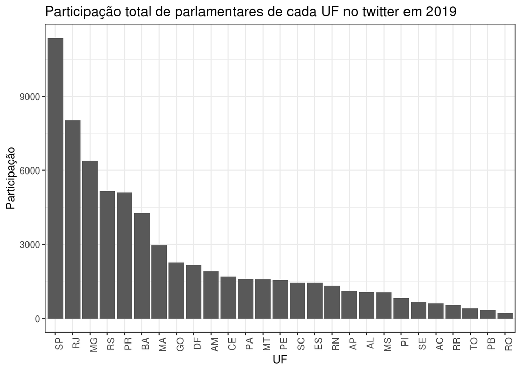

```r
atividade %>%
  filter(!is.na(n_proprio)) %>%
  filter(!is.na(n_retweet)) %>%
  group_by(UF) %>%
  summarise(participacao = sum(n_proprio) + sum(n_retweet), parlamentares = n()) %>%
  ggplot() +
  geom_bar(stat="identity", aes(x = reorder(UF, -participacao), y = participacao)) +
  xlab("UF") +
  ylab("Participação") +
  labs(fill = "UFs") +
  ggtitle("Participação total de parlamentares de cada UF no twitter em 2019") +
  theme(axis.text.x = element_text(angle = 90, hjust = 1))
```

##### A visualização acima respondeu a minha pergunta inicial de quais UFs mais participaram do Twitter, sendo possível observar da esquerda para direita suas posições. As UFs mais participativas foram: SP, RJ, MG, RS e PR.

##### Mas como esses dados só mostram a soma de toda participação dos parlamentares das UFs e o número de parlamentares por UF é difente, me trouxe outro questionamento: **Quais as UFs tiveram mais participação por parlamentar?**

##### Então resolvi observar quantos parlamentares com contas ativas no Twitter cada UF tinha. Plotei os dados em um gráfico de barras e resolvi comparar com o primeiro gráfico gerado.

[figure not shown]

```r
atividade %>%
  filter(!is.na(twitter)) %>%
  group_by(UF) %>%
  summarise(possui_tt = n()) %>%
  ggplot() +
  geom_bar(stat="identity", aes(x = reorder(UF, -possui_tt) , y = possui_tt)) +
  xlab("UF") +
  ylab("Contas") +
  labs(fill = "Contas de twitter por UF") +
  ggtitle("Contas de twitter ativas em 2019 de parlamentares por UF") +
  theme(axis.text.x = element_text(angle = 90, hjust = 1))
```

##### Como foi possível perceber, as UFs que mais tinham parlamentares foram também as que apresentaram maior participação no Twitter. Assim, decidi dividir a participação total de cada UF pelo número de parlamentares do gráfico acima. O resultado foi esse:

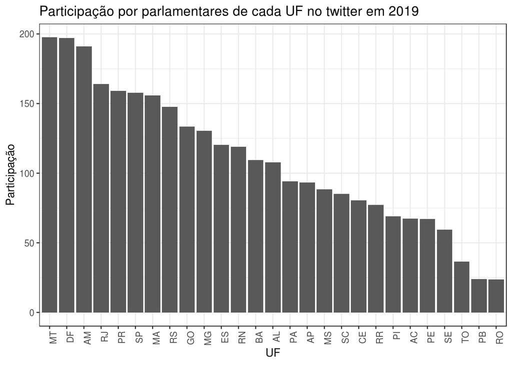

```r
atividade %>%
  filter(!is.na(n_proprio)) %>%
  filter(!is.na(n_retweet)) %>%
  group_by(UF) %>%
  summarise(parlamentares = n(), participacao = (sum(n_proprio) + sum(n_retweet))/parlamentares) %>%
  ggplot() +
  geom_bar(stat="identity", aes(x = reorder(UF, -participacao) , y = participacao)) +
  xlab("UF") +
  ylab("Participação") +
  labs(fill = "UFs") +
  ggtitle("Participação por parlamentares de cada UF no twitter em 2019") +
  theme(axis.text.x = element_text(angle = 90, hjust = 1))
```

##### Foi interessante perceber como UFs que não estavam entre as primeiras posições avançaram para posições com maior participação, e outras que pareciam estar tão à frente caíram no gráfico. Assim, a resposta à questão pode ser conferida observando o gráfico da esquerda para a direita. As cinco UFs que tiveram mais participação por parlamentar foram: MT, DF, AM, RJ e PR.

### Quais foram as UFs que tiveram mais engajamento médio?

##### Já para responder a segunda pergunta inicial, foi preciso calcular o engajamento médio a partir das variáveis disponibilizadas nos dados. Para encontrar o engajamento médio de cada UF foi preciso agrupar os dados por UF e depois fazer a média do engajamento total dos seus respectivos parlamentares. Lembrando que engajamento total diz respeito ao número de likes + número de retweets que os tweets dos parlamentares receberam. Cada parlamentar possui um engajamento total, cuja variável é *engaj_total*.

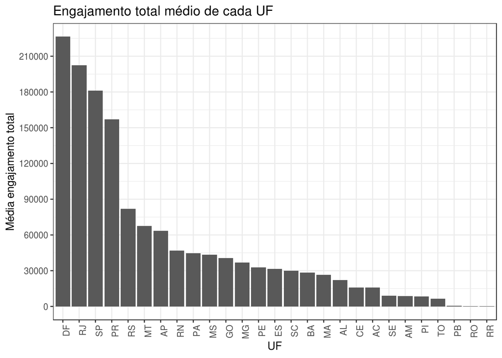

```r
atividade %>%
  filter(!is.na(engaj_total)) %>%
  group_by(UF) %>%
  summarise(parlamentares = n(), media_engaj_total = mean(engaj_total)) %>%
  ggplot(aes(x = reorder(UF, -media_engaj_total), y = media_engaj_total)) +
  geom_bar(stat = "identity") +
  ylab("Média engajamento total") +
  xlab("UF") +
  scale_y_continuous(breaks = seq(0, 250000, by = 30000)) +
  ggtitle("Engajamento total médio de cada UF") +
  theme(axis.text.x = element_text(angle = 90, hjust = 1))
```

##### As UFs com mais engajamento médio total estão em ordem decrescente da esquerda para a direita, sendo a cinco primeiras: DF, RJ, SP, PR e RS.

##### Ao observar o gráfico gerado tive o mesmo questionamento que tive ao visualizar o primeiro gráfico desta análise. Já que o número de parlamentares por UF difere, possivelmente causando maior concentração de dados em UFs com mais parlamentares, então **quais UFs têm mais engajamento médio por parlamentar de cada UF?**

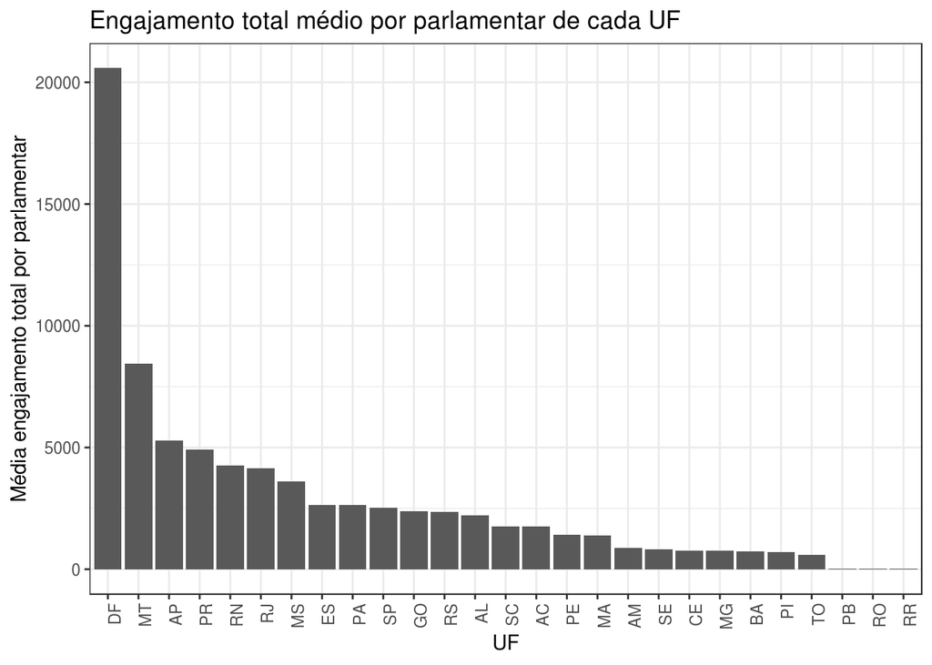

```r
atividade %>%
  filter(!is.na(engaj_total)) %>%
  group_by(UF) %>%
  summarise(parlamentares = n(), media_engaj_total = mean(engaj_total)/parlamentares) %>%
  ggplot(aes(x = reorder(UF, -media_engaj_total), y = media_engaj_total)) +
  geom_bar(stat = "identity") +
  ylab("Média engajamento total por parlamentar") +
  xlab("UF") +
  ggtitle("Engajamento total médio por parlamentar de cada UF") +
  theme(axis.text.x = element_text(angle = 90, hjust = 1))
```

##### A partir do gráfico acima podemos observar as UFs com mais engajamento médio por parlamentar de cada UF estão em ordem decrescente da esquerda para a direita e as cinco primeiras colocadas são: DF, MT, AP, PR e RN.